# Early years introduction to R

18 April 2018

## Introduction

This session is aimed to provide a two hour interactive and introductory session to R. The target audience for this particular version are those working in early year analysis and research unit at the Department for Education (DfE). However the contents can be extrapolated for general purposes.

The contents of this session are based in a large part from the introductory material prepared by the Data Science Team at the Department for Business Energy and Industrial Strategy (BEIS).

This is **not** an in-depth introduction to R, it is designed to provide a quick familiarisation and get interested parties coding as quickly as possible. For those who want to know more there are a plethora of internet resources available.

## Requirements for today's sessions

It is recommended you install at least:

- R version 3.4.2
- R Studio 1.1.383

Both are available from DfE's software center. We will be using R studio throughout.

## What is R

Open source statistical language and environment largely based on S

A tool for data wrangling, modelling, statistical interrogation, visualisation and much more

A way to ensure and support reproducible analysis

More information [here](https://www.r-project.org/about.html)

## R Studio

[figure not shown]

## The basics: files

To open a new script in R Studio go to :

**File** -> **New file** -> **R Script**

Then save it with a title:

**File** -> **Save as**

You can also set a work directory, a place to automatically read and store outputs from, in the command line or as part of the script.

```r
# set your work directory
setwd("C:/Users/KCELLA/Documents/R")

# or see what directory you're working from
getwd()
```

## The basics: comments and code evaluation

It is good practice to comment and annotate your code. You can do this using # before writing a line. Commented code will not be evaluated by R.

```r
# This is a comment
```

To run a line of code type the following into the script or the console:

```r
3 + 1
```

Now hit **Ctrl+return** or or highlight the text and click **'Run'**. R will output the evaluated code:

```
## [1] 4
```

## The basics: assignment and breaks

In R everything is treated like an object. You use the <- sign to assign a value to an object.

```r
my_vector <- c(2, 10, 11, 15)

print(my_vector)
```

```
## [1]  2 10 11 15
```

c() is a standard R function which *combines* elements.

It is also good practice to put section breaks into your code for readability.

```r
# I'm a section break ----------------------------

# Me too =========================================
```

## Date types

- Integer e.g. 1,2,3
- Numeric e.g. 5, -6, 3.1
- Character / string e.g. "Hello world"
- Factor (categorical) e.g. "Red lorry", "Yellow lorry"
- Logical - TRUE / FALSE

## Data structures: vector

The first type of data structure you will work with in R is a vector.

A vector is a one dimensional object that can only contain one type of data.

R is a *vectorised* language which means you can run calculation across the whole vector.

```r
# Create an integer vector
dog_tail_lengths <- c(2, 10, 11, 15)

# apply a calculation over whole vector
3 * dog_tail_lengths
```

```
## [1]  6 30 33 45
```

## Data structures: data frames

Data frames are probably the most common type of object you will work with in R

They are essentially a table which combine vectors together.

```r
# Create a character vector
dog_type <- c("Terrier", "Whippet", "Greyhound", "Great Dane")

# create a data frame for dogs
dogs <- data.frame(dog_type = dog_type, dog_tail_lengths = dog_tail_lengths)

print(dogs)
```

```
##     dog_type dog_tail_lengths
## 1    Terrier                2
## 2    Whippet               10
## 3  Greyhound               11
## 4 Great Dane               15
```

## Data structures: other

- Lists
- Matrices
- Arrays

You can find out more about these data structures by accessing the help through the console. Type and execute as follows:

?list

## Data manipulation: base R vectors

To find the mean of a vector:

```r
# mean on a vector
mean(dog_tail_lengths)
```

```
## [1] 9.5
```

If we want to perform the same operation on a column in a data frame then we reference it using the **$** symbol.

```r
# mean of a data frame column
mean(dogs$dog_tail_lengths)
```

```
## [1] 9.5
```

## Data manipulation: base R data frames

We can find produce a summary of the data frame structure using str()

```r
str(dogs)
```

```
## 'data.frame':    4 obs. of  2 variables:
##  $ dog_type        : Factor w/ 4 levels "Great Dane","Greyhound",..: 3 4 2 1
##  $ dog_tail_lengths: num  2 10 11 15
```

We can also quickly summarise all of the variables using summary()

```r
summary(dogs)
```

```
##        dog_type dog_tail_lengths
##  Great Dane:1   Min.   : 2.0
##  Greyhound :1   1st Qu.: 8.0
##  Terrier   :1   Median :10.5
##  Whippet   :1   Mean   : 9.5
##                 3rd Qu.:12.0
##                 Max.   :15.0
```

## Challenge 1

Find the standard deviation of the dogs tail length from the dogs data frame.

Hint - you should use the sd() function.

## Reading in data

Reading data into R is pretty straight forward. For CSVs you can simply use the read.csv() function.

```r
eyfsp_17 <- read.csv("./data/EYFSP_17_UD_LA.csv", header = TRUE)

head(eyfsp_17)
```

```
##   Country_code Country_name  GOR_code      GOR_name Old_LA_Code
## 1    E92000001      England E12000004 East Midlands         830
## 2    E92000001      England E12000004 East Midlands         831
## 3    E92000001      England E12000004 East Midlands         855
## 4    E92000001      England E12000004 East Midlands         856
## 5    E92000001      England E12000004 East Midlands         857
##   New_LA_Code        LA_Name ELG_1_Emerge ELG_1_Expect ELG_1_Exceed
## 1   E10000007     Derbyshire         1290         5166         2268
## 2   E06000015          Derby          592         2102          810
## 3   E10000018 Leicestershire          961         5087         1863
## 4   E06000016      Leicester          937         2789         1111
## 5   E06000017        Rutland           42          252          110
##   ELG_1_.At.least ELG_2_Emerge ELG_2_Expect ELG_2_Exceed ELG_2_.At.least
## 1            7434         1258         5121         2345            7466
## 2            2912          606         2106          792            2898
```

[output cut: 87 more lines]

## Challenge 2

Can you identify the structure of the data?

What is the mean number of children per local authority who were at the expected level for listening and attention? Variable (ELG_1_Expect).

*Tip*

You can also view your data at any time in R studio by either running the command View(data_name) or by clicking on the object in the environment window.

## Data manipulation: base R filtering

Data frame objects are essentially a series of rows and columns. You can access and select criteria through using the square brackets: e.g. data[,]

Criteria on the left before the comma reflects rows and the right, columns. Example below illustrates how you would filter data to LAs in the east of England.

```r
eyfsp_17_east <- eyfsp_17[eyfsp_17$GOR_name == "East of England",]
head(eyfsp_17_east, 3)
```

```
##    Country_code Country_name  GOR_code        GOR_name Old_LA_Code
## 10    E92000001      England E12000006 East of England         821
## 11    E92000001      England E12000006 East of England         822
## 12    E92000001      England E12000006 East of England         823
##    New_LA_Code              LA_Name ELG_1_Emerge ELG_1_Expect ELG_1_Exceed
## 10   E06000032                Luton          547         2135          666
## 11   E06000055      Bedford Borough          405         1446          462
## 12   E06000056 Central Bedfordshire          411         2485          745
##    ELG_1_.At.least ELG_2_Emerge ELG_2_Expect ELG_2_Exceed ELG_2_.At.least
## 10            2801          573         2113          662            2775
## 11            1908          437         1411          465            1876
## 12            3230          411         2517          713            3230
##    ELG_3_Emerge ELG_3_Expect ELG_3_Exceed ELG_3_.At.least ELG_4_Emerge
## 10          591         2206          551            2757          334
## 11          438         1464          411            1875          258
```

[output cut: 53 more lines]

## Data manipulation: base R filtering

We can also filter based on logic and select only certain columns (variables) to keep.

```r
eyfsp_17_east_listen_expected_high <- eyfsp_17[eyfsp_17$ELG_1_Expect > 1000,
                                               c("GOR_name", "ELG_1_Expect")]
head(eyfsp_17_east_listen_expected_high, 3)
```

```
##        GOR_name ELG_1_Expect
## 1 East Midlands         5166
## 2 East Midlands         2102
## 3 East Midlands         5087
```

You can include multiple conditions when filtering data, for instance by using & for AND conditions and | for OR conditions.

## Writing data

Writing out data is also relatively straight forward in R. For instance to write a csv you simply use the write.csv() function.

We can write out the data we just created as follows:

```r
write.csv(x = eyfsp_17_east, file = "eyfsp_17_east.csv" )
```

This will written into wherever you're working directory is. It is also possible to specify a different directory within the file string, e.g:

"c:/differentfolder/eyfsp_17_east.csv"

## Challenge 3

Create a new R object filtered by LAs within the North East area and where the variable ELG_1_Exceed is > 500.

For a bonus point write the data out to your working directory.

## Tidyverse

A collection of packages for data wrangling, exploration and manipulation.

Intended to make structured R code that guide an individual through a project workflow in a readable way.

A basic philosophy of tidy objects are that rows represent observations and columns variables.

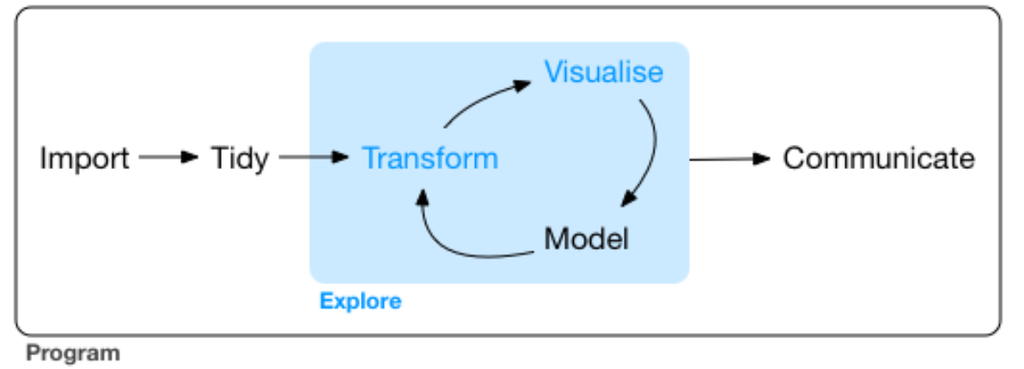

**Source**: [R for Data Science](http://r4ds.had.co.nz/explore-intro.html)

## Installation and calling the tidyverse

As with any R packages you need to install them before the first time you use them:

To install the tidyverse, do the following:

```r
#you only need to do this once
install.packages("tidyverse")
```

To use the packages and the functions included you need to call it into your session as follows:

```r
#you usually need to do this at the start of a new session
library(tidyverse)
```

## Tidyverse packages: dplyr

A core package within the tidyverse is the dplyr package. This package is designed to make manipulating data straight forward and logical. Features of the package include:

| Feature | Explanation |
| --- | --- |
| %>% | Pipe: provides a logical flow to data manipulation |
| filter | Function to filter rows in data set |
| select | Function to select columns in data set |
| mutate | Function to add or manipulate columns |
| arrange | Function to sort data |
| group_by | Function to group by a variable |
| summarise | Summary for grouped data |
| left_join | Left join data sets together as per SQL |

## dplyr: filter

We're going to create the same data frames as before but this time use the filter() function from dplyr.

```r
#base R method
eyfsp_17_east <- eyfsp_17[eyfsp_17$GOR_name == "East of England",]

#filter method
eyfsp_17_east <- filter(eyfsp_17, GOR_name == "East of England")

head(eyfsp_17_east, 3)
```

```
##   Country_code Country_name  GOR_code        GOR_name Old_LA_Code
## 1    E92000001      England E12000006 East of England         821
## 2    E92000001      England E12000006 East of England         822
## 3    E92000001      England E12000006 East of England         823
##   New_LA_Code              LA_Name ELG_1_Emerge ELG_1_Expect ELG_1_Exceed
## 1   E06000032                Luton          547         2135          666
## 2   E06000055      Bedford Borough          405         1446          462
## 3   E06000056 Central Bedfordshire          411         2485          745
##   ELG_1_.At.least ELG_2_Emerge ELG_2_Expect ELG_2_Exceed ELG_2_.At.least
## 1            2801          573         2113          662            2775
## 2            1908          437         1411          465            1876
## 3            3230          411         2517          713            3230
##   ELG_3_Emerge ELG_3_Expect ELG_3_Exceed ELG_3_.At.least ELG_4_Emerge
## 1          591         2206          551            2757          334
## 2          438         1464          411            1875          258
```

[output cut: 53 more lines]

## dplyr: %>% and arrange

We can also use the %>% operator to pipe data between function. For instance we can pipe objects directly into functions, including to arrange the output.

```r
eyfsp_17_east <- eyfsp_17 %>% filter(GOR_name == "East of England") %>%
  arrange(LA_Name)

head(eyfsp_17_east, 3)
```

```
##   Country_code Country_name  GOR_code        GOR_name Old_LA_Code
## 1    E92000001      England E12000006 East of England         822
## 2    E92000001      England E12000006 East of England         873
## 3    E92000001      England E12000006 East of England         823
##   New_LA_Code              LA_Name ELG_1_Emerge ELG_1_Expect ELG_1_Exceed
## 1   E06000055      Bedford Borough          405         1446          462
## 2   E10000003       Cambridgeshire         1061         5038         1534
## 3   E06000056 Central Bedfordshire          411         2485          745
##   ELG_1_.At.least ELG_2_Emerge ELG_2_Expect ELG_2_Exceed ELG_2_.At.least
## 1            1908          437         1411          465            1876
## 2            6572         1065         4903         1665            6568
## 3            3230          411         2517          713            3230
##   ELG_3_Emerge ELG_3_Expect ELG_3_Exceed ELG_3_.At.least ELG_4_Emerge
## 1          438         1464          411            1875          258
## 2         1098         5182         1353            6535          790
```

[output cut: 53 more lines]

## dplyr: select

select() allows you to select only certain columns from a data frame. It is very similar to the SQL select.

```r
eyfsp_17_east_slim <- eyfsp_17 %>% filter(GOR_name == "East of England") %>%
  select(GOR_name, LA_Name, ELG_1_Expect, ELG_1_Exceed)

head(eyfsp_17_east_slim, 5)
```

```
##          GOR_name              LA_Name ELG_1_Expect ELG_1_Exceed
## 1 East of England                Luton         2135          666
## 2 East of England      Bedford Borough         1446          462
## 3 East of England Central Bedfordshire         2485          745
## 4 East of England       Cambridgeshire         5038         1534
## 5 East of England         Peterborough         1633          931
```

## dplyr: mutate

Mutate allows you to add a column or variable to your data frame

```r
eyfsp_17_east_slim_EE <- eyfsp_17_east_slim %>%
  mutate(total_expect_exceed = ELG_1_Expect + ELG_1_Exceed)

head(eyfsp_17_east_slim_EE, 5)
```

```
##          GOR_name              LA_Name ELG_1_Expect ELG_1_Exceed
## 1 East of England                Luton         2135          666
## 2 East of England      Bedford Borough         1446          462
## 3 East of England Central Bedfordshire         2485          745
## 4 East of England       Cambridgeshire         5038         1534
## 5 East of England         Peterborough         1633          931
##   total_expect_exceed
## 1                2801
## 2                1908
## 3                3230
## 4                6572
## 5                2564
```

## dplyr: group_by and summarise

group_by() and summarise() are often used in conjunction with each other and allow you to group data by elements in a column and summarise the results. For instance, to ascertain the average number of exceeded children by region:

```r
eyfsp_17 %>% group_by(GOR_name) %>% summarise(average_exceeded = mean(ELG_1_Exceed))
```

```
## # A tibble: 10 x 2
##                    GOR_name average_exceeded
##                      <fctr>            <dbl>
##  1            East Midlands        1398.4444
##  2          East of England        1548.0000
##  3             Inner London         567.3571
##  4               North East         627.0833
##  5               North West         826.5217
##  6             Outer London         910.5263
##  7               South East        1414.1579
##  8               South West         943.4000
##  9            West Midlands        1092.5000
## 10 Yorkshire and The Humber         994.8667
```

## Challenge 4

Using the dplyr tool kit find the standard deviation for the combined number of children who were emerging and expected for the listening and attention (ELG_1_Emerge, ELG_1_Expect), grouped by English region.

*HINT*

You will need to use the sd(), mutate(), group_by() and summarise() functions.

## Challenge 4

```r
eyfsp_17 %>%
  mutate(total_expect_emerge = ELG_1_Expect + ELG_1_Emerge) %>%
  group_by(GOR_name) %>% summarise(sd_EE = sd(total_expect_emerge))
```

```
## # A tibble: 10 x 2
##                    GOR_name     sd_EE
##                      <fctr>     <dbl>
##  1            East Midlands 2569.1100
##  2          East of England 3995.9838
##  3             Inner London 1044.4138
##  4               North East  885.6032
##  5               North West 1976.0707
##  6             Outer London  755.7647
##  7               South East 3971.2810
##  8               South West 1674.2613
##  9            West Midlands 3083.7545
## 10 Yorkshire and The Humber 1819.4519
```

## Plotting sneak peak: ggplot2

Another package within the tidyverse is ggplot2 which allows you to create plots based on the [grammar of graphics](https://ramnathv.github.io/pycon2014-r/visualize/ggplot2.html).

We can pipe straight into ggplot2 from dplyr to visualise our results:

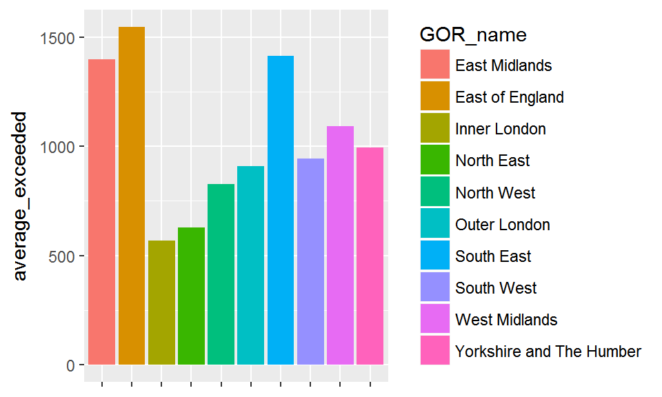

```r
eyfsp_17 %>% group_by(GOR_name) %>% summarise(average_exceeded = mean(ELG_1_Exceed)) %>%
  ggplot(data =.) +
  geom_bar(aes(x = GOR_name, y = average_exceeded, fill = GOR_name), stat ="identity")+
  theme(axis.title.x=element_blank(), axis.text.x=element_blank())
```

## Further resources:

That's the end of this introductory session, I would personally recommend the following R resources:

- Data camp [intro to R course](https://www.datacamp.com/courses/free-introduction-to-r)
- [DfE introduction course] (https://dfe-analytical-services.github.io/r-training-course/)
- The [R for data science book](http://r4ds.had.co.nz/)

Finally, the great thing about R and open source software is the community support. If you are struggling then google search really is your friend, I can guarantee someone else has almost certainly had the same problem before and posted about it.